# The data science workflow with Tidyverse

[figure not shown]

## Packages & Functions

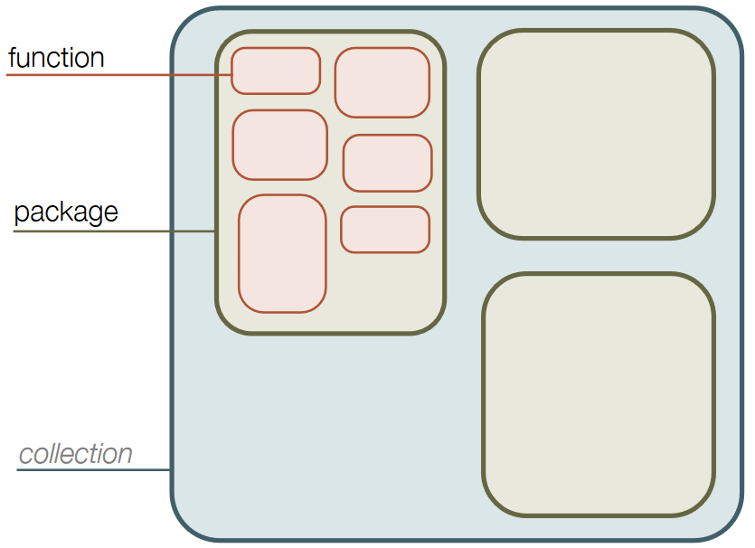

## Packages & Functions

[interactive chart not shown]

## Packages & Functions

1. Installing a package (once):

```r
install.packages("dplyr")
```

2. Loading a package (every time you want to use it):

```r
library(dplyr)
```

3. Now you can use functions from this package! (every time you want to use it)

```r
dplyr::rename(iris, petal_length = Petal.Length)
```

```
    Sepal.Length Sepal.Width petal_length Petal.Width    Species
1            5.1         3.5          1.4         0.2     setosa
2            4.9         3.0          1.4         0.2     setosa
3            4.7         3.2          1.3         0.2     setosa
4            4.6         3.1          1.5         0.2     setosa
5            5.0         3.6          1.4         0.2     setosa
6            5.4         3.9          1.7         0.4     setosa
7            4.6         3.4          1.4         0.3     setosa
8            5.0         3.4          1.5         0.2     setosa
9            4.4         2.9          1.4         0.2     setosa
10           4.9         3.1          1.5         0.1     setosa
11           5.4         3.7          1.5         0.2     setosa
12           4.8         3.4          1.6         0.2     setosa
13           4.8         3.0          1.4         0.1     setosa
14           4.3         3.0          1.1         0.1     setosa
```

[output cut: 136 more lines]

## What is the tidyverse?

> The tidyverse is an opinionated collection of R packages **designed for data science**. All packages **share an underlying design** philosophy, grammar, and data structures ([tidyverse.org](https://www.tidyverse.org/)).

[figure not shown]

## tidyverse core packages

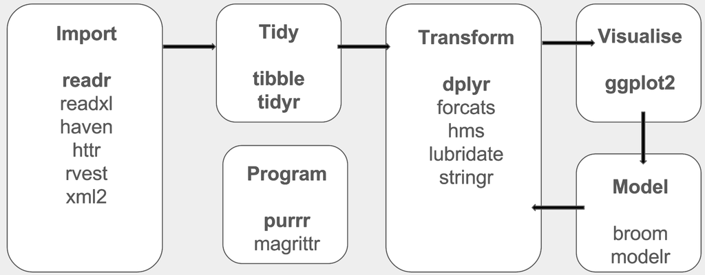

# 🐧🐧🐧

## Afternoon workflow

1. Read a file into R
2. Clean the data:
   - Select only relevant columns
   - Filter on relevant rows
3. Calculate a new column
4. Rename a column
5. Put the dataframe into a long (tidy) format
6. Summarize the dataframe
7. Visualize the dataframe
8. Write the summarized dataframe to a file

## Data: palmerpenguins

- Observations about penguins from the Palmer Archipelago (Antarctica)
- Package created by Allison Horst for worldwide use
- species, island, culmen length and depth, flipper length, etc.

# Importing Data

## Reading data into R

[figure not shown]

## readr: Read Rectangular Text Data

[figure not shown]

[figure not shown]

## readr: Read Rectangular Text Data

To read text data, you need:

- **location** of the data (path)
- **delimiter** (value separator) of the data, e.g. `,`, `;` or `\t`
- **function** to use to read data into R

| Read *from* file | Write *to* file | Value separator |
| --- | --- | --- |
| `read_delim()` | `write_delim()` | catch-all: user needs to specify |
| `read_csv()` | `write_csv()` | comma separated |
| `read_csv2()` | `write_csv2()` | semicolon separated |
| `read_tsv()` | `write_tsv()` | tab separated |

## Reading non-text data file

For non-text data files, there are other R packages:

- `readxl`: Excel files
- `haven`: SPSS & STATA files
- `googlesheets4`: Google Sheets
- `rvest`: HTML files

## Example: reading data

Read a file located in the same folder as your script:

```r
raw_tsv_data <- read_tsv("my_raw_data.tsv")
```

Read a file located in a different folder:

```r
raw_csv_data <- read_csv("data/raw/my_raw_data.csv")
```

Or from the web:

```r
# Source: https://catalog.data.gov/dataset/electric-vehicle-population-data
electric_vehicles <- read_csv("https://data.wa.gov/api/views/f6w7-q2d2/rows.csv")
```

Bonus: use an in-built dataset from R

```r
data(iris)        # Observational data on iris flowers
data(mtcars)      # Motor Trend Car Road Tests

data()            # Check all the available in-built datasets!
```

# Go to Exercise 1, 2 and 3

## Answers Exercise 1, 2 and 3

1. Reading the penguins dataset into R.

```r
penguins <- read_tsv("data/penguins.tsv")
```

2. Reading penguins_isotopes.xlsx into R.

```r
penguins_isotopes <- read_excel(path = "data/penguins_isotopes.xlsx")
```

3. Writing `penguins_isotopes` to a csv file.

```r
write_csv(penguins_isotopes,
          file = "data/penguins_isotopes.csv")
```

# Selecting & filtering data

## dplyr: Data Manipulation

`dplyr` contains functions for many types of data manipulation, such as:

- `filter()`: select **rows** that meet one or several logical criteria
- `select()`: select (or drop) **columns**
- `rename()`: change column name
- `mutate()`: transform column values or create new column
- `group_by()`: group data on one or more columns
- `summarize()`: reduces a group of data into a single row

## Select

Select or drop **columns** in your dataframe.

Basic use:

```r
select(your-dataframe, week1, week2)  # select the week1 & week2 columns
```

```r
select(your-dataframe, -week3)       # select all columns, except week3
```

Use special [selecting functions](https://tidyselect.r-lib.org/reference/language.html)

```r
select(your-dataframe, contains("week"))    # select columns containing "week"
```

From the morning session: “Return the columns `name` and `age` together.”

```r
df[, c("name","age")]       # Base R
```

```r
select(df, name, age)       # Tidyverse
```

```
   name age
1   Ann  15
2   Bob  22
3 Chloe  50
4   Dan  51
```

## Filter

Selects **rows** in your dataframe.

Use:

```r
filter(your-dataframe, your-condition)
```

From the morning session: “From your dataframe `df`, return complete rows for everyone living in a country of your choice.”

```r
df[df$country=="UK", ]        # Base R
```

```r
filter(df, country == "UK")   # Tidyverse
```

```
  name age country
1  Ann  15      UK
2  Dan  51      UK
```

# Go to exercises 4 and 5

## Answers exercise 4

4. Select the columns Individual_ID, Species, Sex, Island, Culmen_Depth_mm and Culmen_Length_mm

```r
penguins_subset <- select(penguins, Individual_ID, Species,
                            Sex, Island,
                            Culmen_Depth_mm, Culmen_Length_mm)
```

Or

```r
penguins_subset <- select(penguins, Individual_ID, Species,
                            Sex, Island,
                            starts_with("Culmen"))
```

Or

```r
penguins_subset <- select(penguins, Individual_ID, Species,
                            Sex, Island,
                            contains("Culmen"))
```

## Answers exercise 5

5. Filter `penguins` to leave out the NAs.

```r
penguins_subset_2 <- filter(penguins_subset, !is.na(Sex))
```

Or

```r
penguins_subset_2 <- filter(penguins_subset, Sex == "MALE" | Sex == "FEMALE")
```

Or

```r
penguins_subset_2 <- filter(penguins_subset, Sex %in% c("MALE", "FEMALE"))
```

## Mutate

Transform column values, or create new column.

Basic use:

```r
mutate(your-dataframe, column_name = an_operation)
```

Add a new column:

```r
df$old_age <- df$age + 20           # Base R
```

```r
df <- mutate(df, old_age = age + 20) # Tidyverse
```

## Rename

Renaming columns.

Basic use:

```r
rename(your-dataframe, new_column_name = old_column_name)
```

Rename a column:

```r
df$Old_Age <- df$old_age          # Base R
```

```r
df <- rename(df, Old_Age = old_age) # Tidyverse
df
```

```
   name age country Old_Age
1   Ann  15      UK      35
2   Bob  22     USA      42
3 Chloe  50     USA      70
4   Dan  51      UK      71
```

# Go to Exercise 6 and 7

## Answers exercises 6 and 7

6. Use `mutate()` to create a new column `culmen_ratio`.

```r
penguins_subset_3 <- mutate(penguins_subset_2,
                            culmen_ratio = Culmen_Length_mm / Culmen_Depth_mm)
```

7. Rename the columns `Culmen_Length_mm` and `Culmen_Depth_mm`.

```r
penguins_subset_4 <- rename(penguins_subset_3,
                            length = Culmen_Length_mm,
                            depth = Culmen_Depth_mm)
```

# Piping Operations

## magrittr: The Forward-Pipe Operator %>%

A key tidyverse component that chains all data science steps together:

`%>%`<sup>1</sup>

Why?

- create an easily readable **pipeline of chained commands**
- no nested function calls
- no need to save intermediate R objects with `<-`
- easily add and/or delete steps in your pipeline without breaking the code
[^1]: Base R now also has a piping operator: `|>`  
    which [works very similarly](https://www.tidyverse.org/blog/2023/04/base-vs-magrittr-pipe/) to the magrittr piping operator `%>%`

## Pipe operator: how it works

```r
# Name the object that you use as initial input
my_new_df <- df %>%

  # Perform a function using that object as input
  select(name, age) %>%

  # Add another operation
  filter(country == "UK") %>%

  # And another, etc.
  mutate(old_age = age + 20)
```

Note:

- `df` is only mentioned once at the beginning
- final line of the operation does not get a `%>%`

# Go to exercise 8

[figure not shown]

## Answers exercise 8

Make a workflow that starts with the data `penguins` and subsequently applies your `filter`, `select`, `mutate` and `rename` operations.

```r
penguins_subset_5 <- penguins %>%

  # Select only relevant columns
  select(Individual_ID, Species, Sex, Island, starts_with("Culmen")) %>%

    # Filter out NAs
  filter(!is.na(Sex)) %>%

  # Add a new columns culmen_ratio
  mutate(culmen_ratio =  Culmen_Length_mm / Culmen_Depth_mm) %>%

  # Rename Culmen measurement columns
  rename(length = Culmen_Length_mm,
         depth = Culmen_Depth_mm)
```

# Reshaping Data

## Long vs. Wide Data

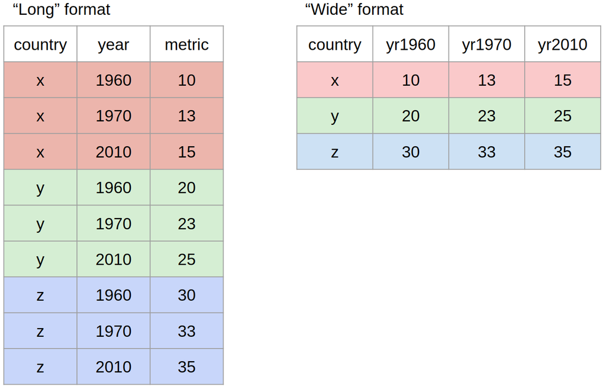

source: https://tavareshugo.github.io/r-intro-tidyverse-gapminder/

## Long vs. Wide Data

### Wide Data

**PROS**

- Useful for summaries and reports
- Efficient for simple comparisons across categories
- Easier to read at a glance

**CONS**

- Becomes unwieldy with many variables or time points
- Not suitable for many statistical or machine-learning models

### Long Data

**PROS**

- Ideal for analysis and visualization
- Works well with `tidyverse`-aligned packages
- Flexible manipulation with easy grouping & summarization

**CONS**

- Harder to interpret at a glance
- Can be computationally heavy for large datasets

## tidyr: Tidy Messy Data

Do It Yourself:

- `pivot_longer()`: lengthen data: more rows, often fewer columns (long format, tidy)
- `pivot_wider()`: widen data: fewer rows, often more columns (wide format)

Basic use:

```r
pivot_longer(your-dataframe, cols = c(col_to_pivot1, col_to_pivot2, etc),
            names_to = "name_of_measurement",
            values_to = "values_of_measurement")
```

Check `?pivot_longer()` and Google! for examples and other function arguments.

## tidyr: Tidy Messy Data

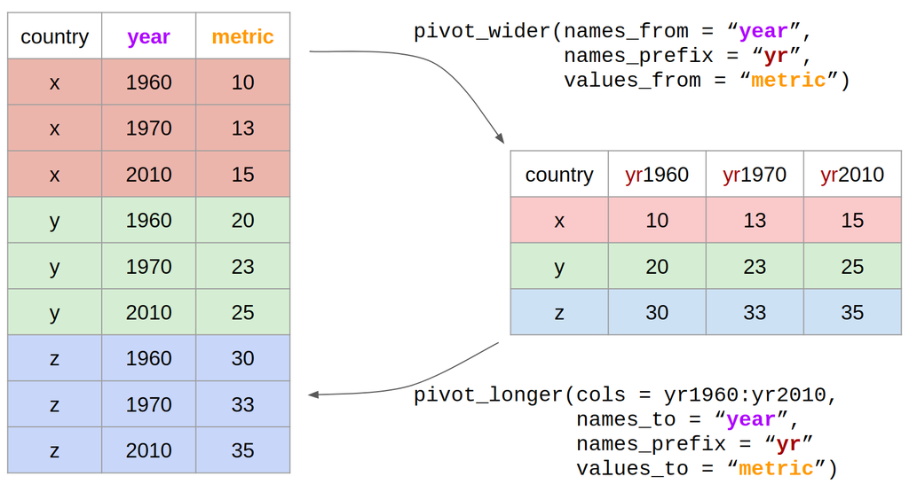

source: https://tavareshugo.github.io/r-intro-tidyverse-gapminder/

# Go to Exercise 9

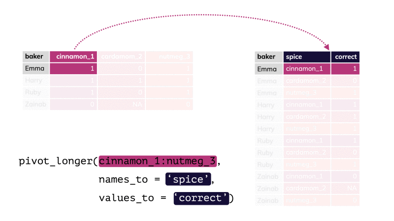

*Source: [Allison Hill](https://github.com/apreshill/teachthat/blob/master/pivot/pivot_longer_smaller.gif)*

## Answer exercise 9

Transform the dataframe from wide to long format using the function `pivot_longer()`.

```r
penguins_long <- penguins_subset_5 %>%
  pivot_longer(cols = c(length, depth),
               names_to = "culmen_element",
               values_to = "measurement")
```

# Summarizing and combining data

## Our df from the morning - but extended

```
   name age country mood_wk1 mood_wk2
1   Ann  15      UK        4        2
2   Bob  22     USA        3        3
3 Chloe  50     USA        4        5
4   Dan  51      UK        2        4
```

## Our df from the morning - but extended + pivoted

```
# A tibble: 8 × 5
  name    age country  week  mood
  <chr> <dbl> <chr>   <dbl> <dbl>
1 Ann      15 UK          1     4
2 Ann      15 UK          2     2
3 Bob      22 USA         1     3
4 Bob      22 USA         2     3
5 Chloe    50 USA         1     4
6 Chloe    50 USA         2     5
7 Dan      51 UK          1     2
8 Dan      51 UK          2     4
```

## group_by() and summarize()

Group by one or more columns and perform some summarizing operation.

Basic use:

```r
group_by(your-dataframe, column1_to_group_by, column2_to_group_by, [etc])
summarize(your-dataframe, new_column = <some_summarizing_operation>)
```

Example 1:

```r
df_ext %>%
    group_by(country) %>%
    summarize(count = n())
```

```
# A tibble: 2 × 2
  country count
  <chr>   <int>
1 UK          2
2 USA         2
```

Example 2

```r
df_long %>%
    group_by(week) %>%
    summarize(avg_mood = mean(mood))
```

```
# A tibble: 2 × 2
   week avg_mood
  <dbl>    <dbl>
1     1     3.25
2     2     3.5
```

## Combining data (joins)

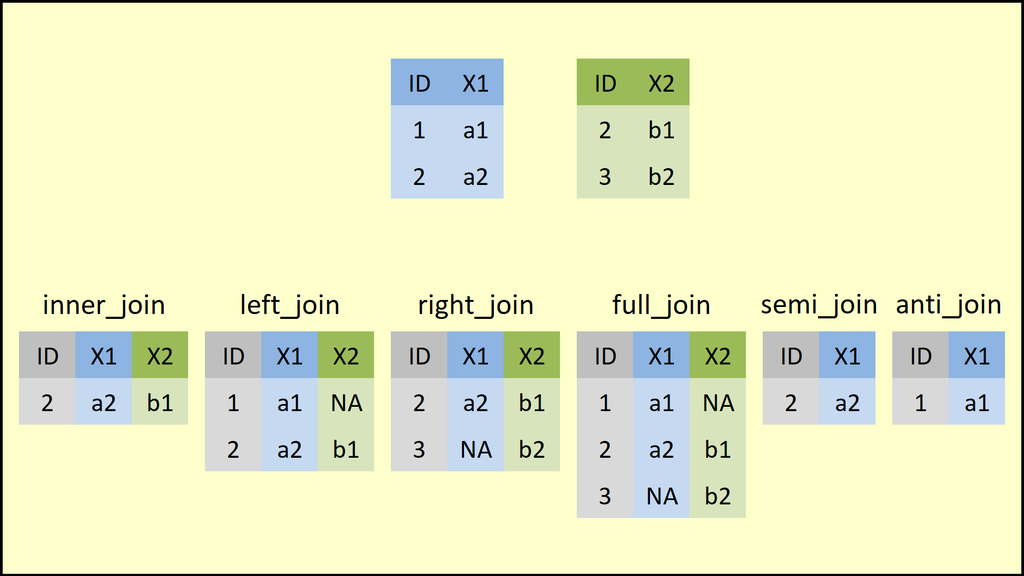

Read more about joins in [R for Data Science](https://r4ds.hadley.nz/joins#how-do-joins-work). Today, we’ll focus on `full_join()`.

# Go to Exercises 10 and 11

## Answers Exercises 10 and 11

10. Use `group_by()` and `summarize()` to calculate the mean and standard deviation of all measurements, grouped by species and the type of measurement.

```r
penguins_summary <- penguins_long %>%
  group_by(Species, culmen_element) %>%
  summarize(avg = mean(measurement),
            sd = sd(measurement))
```

11. Merge `penguins_summary` and `penguins_long`.

```r
penguins_join <- full_join(penguins_summary, penguins_long,
                           by = c("Species", "culmen_element"))
```

# Data Visualization

## ggplot2: Elegant Data Visualisations

- `ggplot2` is Hadley Wickham’s [reimplementation](https://doi.org/10.1198/jcgs.2009.07098) of *The Grammar of Graphics* (Leland Wilkinson, 2005).
- MANY functions to generate MANY graphs
- Graphs built up from multiple layers

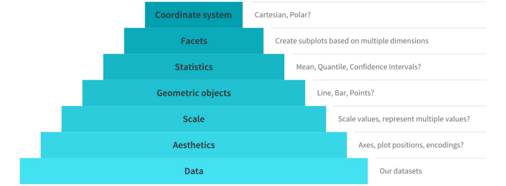

*Source: [towardsdatascience](https://towardsdatascience.com/a-comprehensive-guide-to-the-grammar-of-graphics-for-effective-visualization-of-multi-dimensional-1f92b4ed4149)*

## Our first plots - data

Remember `df_ext`?

```r
df_ext
```

```
   name age country mood_wk1 mood_wk2
1   Ann  15      UK        4        2
2   Bob  22     USA        3        3
3 Chloe  50     USA        4        5
4   Dan  51      UK        2        4
```

And `df_long`?

```r
df_long
```

```
# A tibble: 8 × 5
  name    age country  week  mood
  <chr> <dbl> <chr>   <dbl> <dbl>
1 Ann      15 UK          1     4
2 Ann      15 UK          2     2
3 Bob      22 USA         1     3
4 Bob      22 USA         2     3
5 Chloe    50 USA         1     4
6 Chloe    50 USA         2     5
7 Dan      51 UK          1     2
8 Dan      51 UK          2     4
```

## Our first plot

First layer: the data

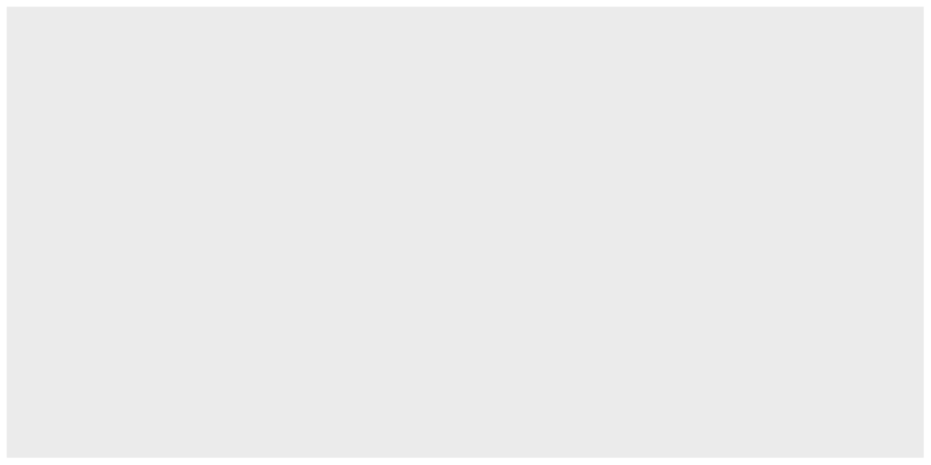

```r
ggplot(df_ext)
```

## Our first plot

Second layer: aesthetics

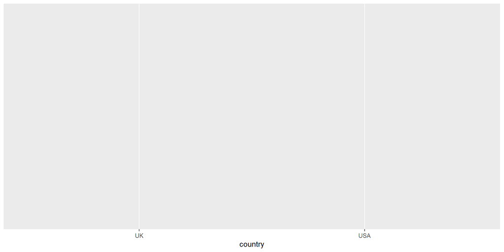

```r
ggplot(df_ext) +
  aes(x = country)
```

## Our first plot

Third layer: geom

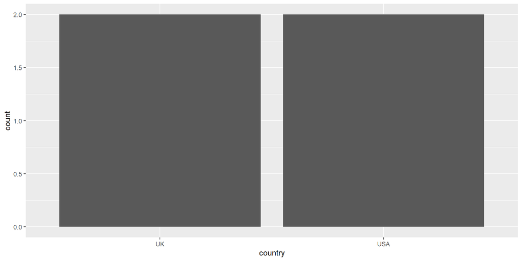

```r
ggplot(df_ext) +
  aes(x = country) +
  geom_bar()
```

## Our first plot

Another layer: labels

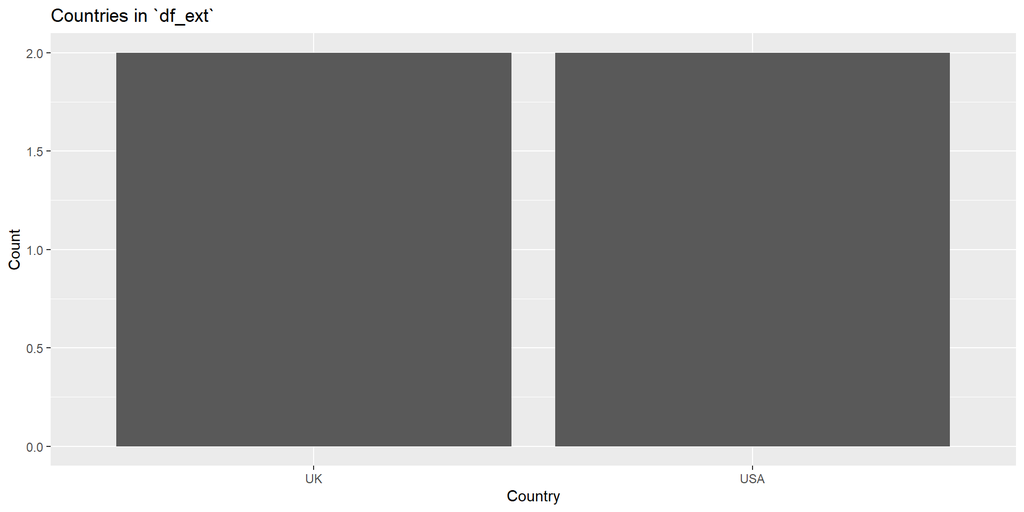

```r
ggplot(df_ext) +
  aes(x = country) +
  geom_bar() +
  labs(title="Countries in `df_ext`",
       x ="Country",
       y = "Count")
```

## Our second plot

Turn week into character (to prevent ugly plotting) + plot data.

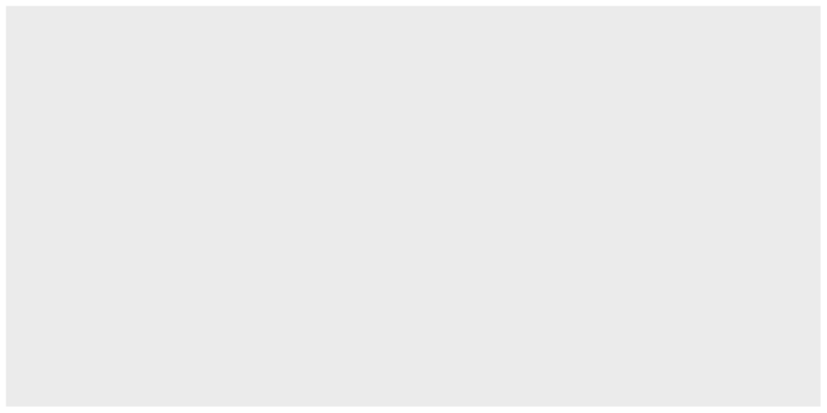

```r
df_long %>%
  mutate(week = as.character(week)) %>%
  ggplot()
```

## Our second plot

Add aesthetics.

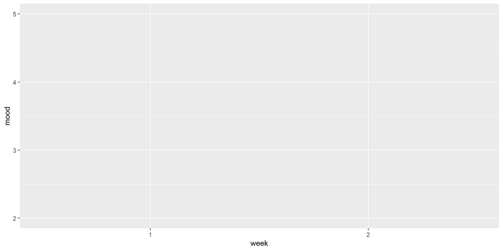

```r
df_long %>%
  mutate(week = as.character(week)) %>%
  ggplot() +
  aes(x = week, y = mood)
```

## Our second plot

Add a geom.

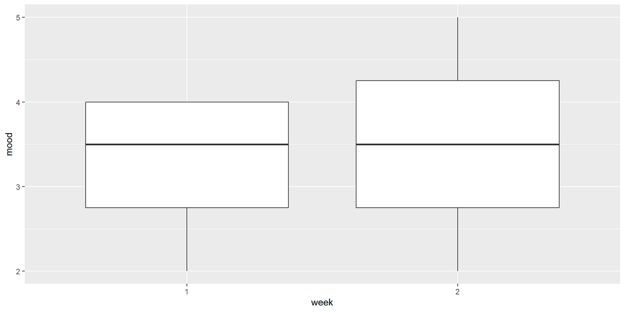

```r
df_long %>%
  mutate(week = as.character(week)) %>%
  ggplot() +
  aes(x = week, y = mood) +
  geom_boxplot()
```

## Our second plot

Create a separate plot per country.

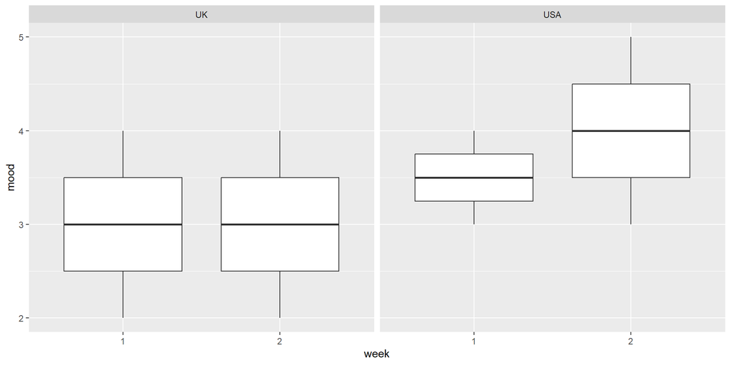

```r
df_long %>%
  mutate(week = as.character(week)) %>%
  ggplot() +
  aes(x = week, y = mood) +
  geom_boxplot() +
  facet_wrap(~ country)
```

## Our second plot

Use a nicer theme.

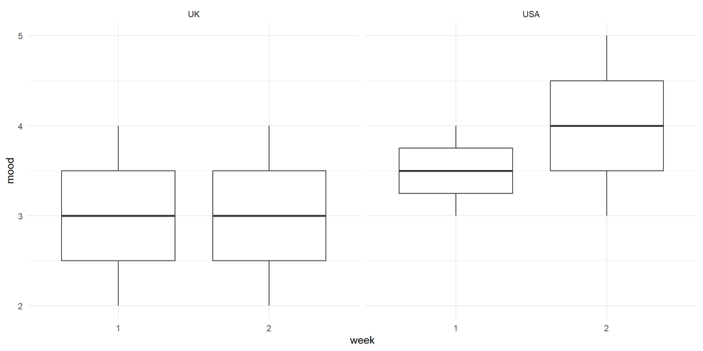

```r
df_long %>%
  mutate(week = as.character(week)) %>%
  ggplot() +
  aes(x = week, y = mood) +
  geom_boxplot() +
  facet_wrap(~ country) +
  theme_minimal()
```

## Our second plot

Larger text

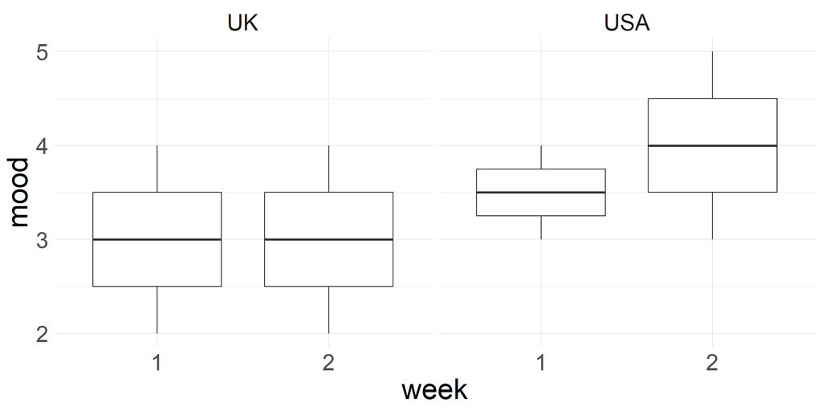

```r
df_long %>%
  mutate(week = as.character(week)) %>%
  ggplot() +
  aes(x = week, y = mood) +
  geom_boxplot() +
  facet_wrap(~ country) +
  theme_minimal() +
  theme(text = element_text(size = 25))
```

# Go to Exercise 12 - 13

Tip: Choose a visualization -> Get example code: https://www.data-to-viz.com/

## Answers to Exercise 12

A scatterplot of Culmen_Length_mm against Flipper_Length_mm per Island.

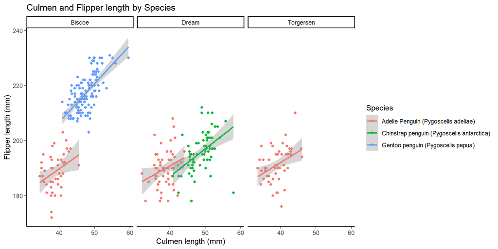

```r
ggplot(penguins, aes(x = Culmen_Length_mm,
                     y = Flipper_Length_mm,
                     color = Species)) +
  geom_point() +
  labs(x = "Culmen length (mm)",
       y = "Flipper length (mm)",
       title = "Culmen and Flipper length by Species") +
  theme_classic() +
  facet_wrap( ~ Island) +
  geom_smooth(method = "lm")
```

## Wrap-up

What have we learned this afternoon?

- Packages vs. functions
- Reading data into R: `read_csv()`, `read_tsv()`, `read_excel()`
- Writing R objects to a csv file: `write_csv`
- Wrangling data with `filter()`, `select()`, `mutate()`, `rename()`
- Chaining operations together with `%>%`
- Creating tidy data
- Summarizing and combining datasets
- Using `ggplot2` to make some basic plots

## Learn more

- R 4 Data Science: https://r4ds.hadley.nz/
- Data Science in a Box: https://datasciencebox.org/content
- Learning statistics with R: https://learningstatisticswithr.com/book/
- Statistical Inference via Data Science: A ModernDive into R and the Tidyverse: https://moderndive.com/
- Big Book of R: https://www.bigbookofr.com/
- Better spreadsheets: https://better-spreadsheets.netlify.app/
- [YaRrr! The Pirate’s Guide to R](https://bookdown.org/ndphillips/YaRrr/)

**See also the [What’s next page](https://utrechtuniversity.github.io/workshop-introduction-to-R-and-data/what-next.html).**

## Where to find us

- Our website: [uu.nl/rdm](https://uu.nl/rdm/)
- [Weekly Walk-in Hours Research Data & Software](https://www.uu.nl/en/research/research-data-management/workshops/walk-in-hours-research-data-and-software)
- [Monthly Programming Cafe](https://www.uu.nl/en/research/research-data-management/workshops/programming-cafe)
- Or contact us for support: info.rdm@uu.nl

# Thank you!

```r
useR <- function(){
  print("Good luck and see you!")
}

useR()
```

```
[1] "Good luck and see you!"
```